# Human ratings of complexity of pictographic characters: Oracle vs Traditional

This notebook analyzes data from a preregistered experiment that compared the complexity of traditional characters to their counterparts from the Oracle Bones period. There are two conditions: `handwritten` (handwritten traditional characters) and `printed` (traditional characters printed in Hiragino Sans GB). The Oracle forms are the same in both conditions.

```r
library(tidyverse)
library(here)
library(lme4)
library(brms)
library(showtext)
library(ggimage)
library(ggrepel)
library(ropencc)
library(ggpubr)
library(xtable)

select <- dplyr::select
showtext_auto()
```

```r
dpathfont <- here("experiment", "data", "data_pictographic_ratings_oracle_printedtraditional.csv")
dpathhw <- here("experiment", "data", "data_pictographic_ratings_oracle_hwtraditional.csv")

font_add("hiragino", "Hiragino Sans GB.ttc")

mytheme <-  theme_classic(base_size = 10)  +
            theme(strip.background = element_blank()) +
            theme(axis.text.y = element_text("hiragino", NULL, NULL, NULL))

theme_set(mytheme)

# Path to the main complexity file. May need to be adjusted depending on where you put all_complexities.csv after downloading the Zenodo folder
dpath_all <-  here("data", "complexities", "all_complexities.csv")

suffix = "pad"
```

First we look at how many participants in each condition met the inclusion criterion (responses to the 5 check pairs must all be correct)

```r
dall <- read_csv(dpathfont) %>%
  bind_rows(read_csv(dpathhw)) %>%
  mutate(origcondition = condition) %>%
  mutate(condition = if_else(condition=="traditional", "printed", "handwritten"))

inclusion_summary <- dall %>%
  select(participantid, condition, controlscore)  %>%
  unique() %>%
  group_by(condition, controlscore) %>%
  summarize(counts = n())

print(inclusion_summary)
```

```
## # A tibble: 12 × 3
## # Groups:   condition [2]
##    condition   controlscore counts
##    <chr>              <dbl>  <int>
##  1 handwritten            0      1
##  2 handwritten            1      1
##  3 handwritten            2      1
##  4 handwritten            3      5
##  5 handwritten            4     21
##  6 handwritten            5    170
##  7 printed                0      5
##  8 printed                1      1
##  9 printed                2      5
## 10 printed                3     14
## 11 printed                4     42
## 12 printed                5    132
```

In the handwritten condition 170 out of 199 participants meet the criterion. In the printed condition 132 out of 199 participants meet the criterion. All remaining analyses include only participants who met the criterion.

We recruited 200 participants in each condition but responses of one participant in each condition were not recorded due to server error.

Let’s start with a basic plot to show the distribution of responses in each condition.

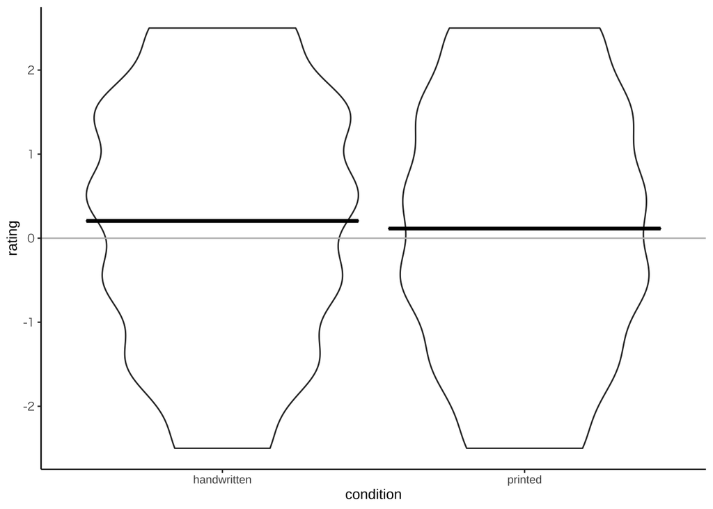

```r
dexp <- dall %>%
 filter(controlscore == 5) %>%
 mutate(rating = rating-2.5) %>%
 mutate(binrating=rating>0) %>%
 filter(!str_detect(character, "^control_")) %>%
 group_by(condition, character) %>%
 mutate(cmean = mean(rating)) %>%
 ungroup() %>%
 mutate(limage = here("experiment", "stimuli", "oracle", paste0(character, "_oracle.png")),
        rimage = here("experiment", "stimuli", origcondition, paste0(character, "_", origcondition, ".png")))

expsumm <- dexp %>%
  select(character, condition, cmean) %>%
  unique() %>%
  group_by(condition) %>%
  mutate(r = rank(cmean)) %>%
  mutate(plotlab = if_else(character %in% c("山", "车", "雨", "龟"), character, ''))

conditionsummaryplot <- dexp %>%
  ggplot(aes(condition, rating )) +
  geom_violin(adjust=2)  +
  geom_hline(yintercept=0, color="grey") +
  stat_summary(fun.y = mean, fun.ymin = mean, fun.ymax = mean, geom="crossbar")

conditionsummaryplot
```

Responses of 3 or higher indicate cases where the traditional form was chosen as more complex. Chance performance would produce an average of 2.5 (grey line). The data suggest that traditional forms tended to be judged as more complex, but the effect is relatively small (and smaller in the printed condition than the handwritten condition).

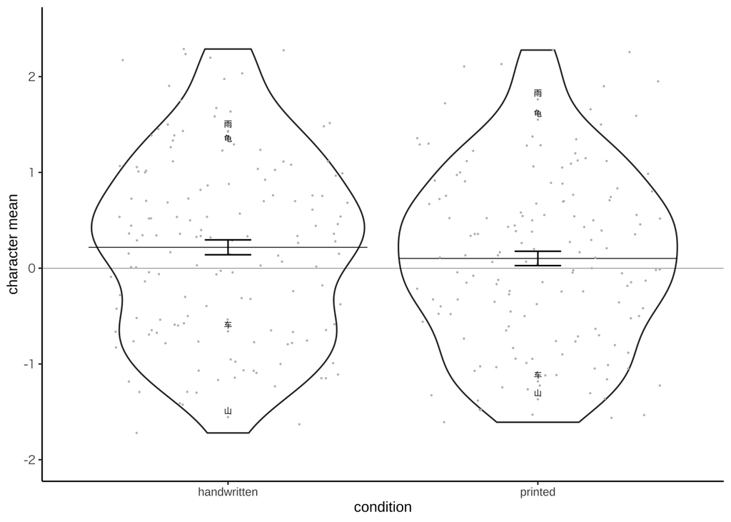

```r
expsummnolab <- expsumm %>%
  filter(plotlab == "")

expsummlab <- expsumm %>%
  filter(plotlab != "")

conditioncmeanplot <- expsummnolab %>%
  ggplot(aes(condition, cmean, label=plotlab)) +
  geom_violin() +
  geom_hline(yintercept=0, color="black", size=0.1) +
  stat_summary(fun.y = mean, geom="crossbar", fatten=0.5) +
  geom_point(alpha=1.0, width=0.0, colour="gray", size=0.1, position = position_jitter(seed = 0))+
  geom_point(data = expsummlab, alpha=1.0, width=0.2, colour="gray", size=0.1)+
  geom_text_repel(data = expsummlab, direction = "y", size=2,  box.padding = 0.1, nudge_y = 0.001)+
  stat_summary(geom="errorbar", width=0.15)+
  ylim(-2.0, 2.5) +
  ylab('character mean')

conditioncmeanplot
```

Let’s now look at the responses for individual characters. First we make Fig S3:

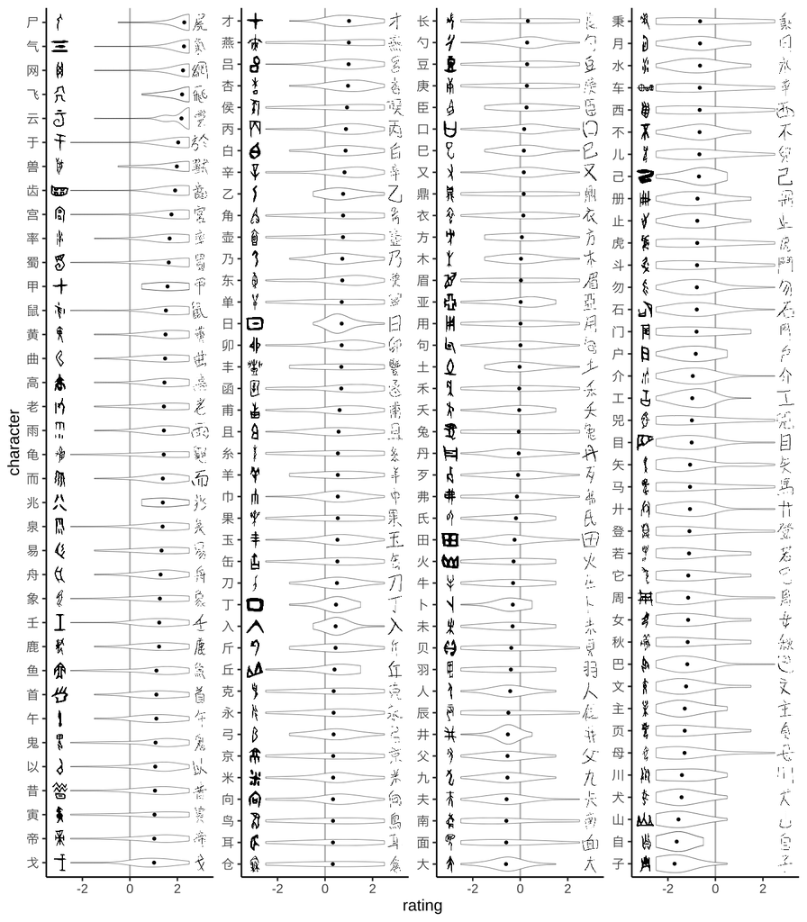

```r
data_handwritten <- dexp %>%
  filter(condition == "handwritten") %>%
  mutate(character = fct_reorder(character, cmean))  %>%
  group_by(character) %>%
  mutate(charid = cur_group_id()) %>%
  mutate(plotgroup = 4 - charid %/% 40 )

data_printed <- dexp %>%
  filter(condition == "printed") %>%
  mutate(character = fct_reorder(character, cmean) )  %>%
  group_by(character) %>%
  mutate(charid = cur_group_id()) %>%
  mutate(plotgroup = 4 - charid %/% 40 )

pairplot_hwtrad <- data_handwritten %>%
  ggplot(aes(character, rating)) +
  geom_hline(yintercept=0, color="grey") +
  geom_violin(adjust=2, size=0.1) +
  facet_wrap(~plotgroup, scales="free_y", ncol=4) +
  stat_summary(fun.y=mean, geom="point", size=0.5) +
  geom_image( aes(x=character, y=2.95, image = rimage),
              size = 0.02, by = "height", asp = (1.5)/8
              )  +
   geom_image( aes(x=character, y=-2.95, image = limage),
              size = 0.02, by = "height", asp = (1.5)/8
              )  +
  ylim(-3.2, 3.2) +
  coord_flip()  +
  theme(
  strip.text.x = element_blank()
  )

pairplot_hwtrad
```

```r
ggsave(here("figures", "figs3_exp_ratings_bycharacter_hwtrad.png"), plot = pairplot_hwtrad, width = 7,height = 8)
```

And the same plot for the printed condition (Fig S4):

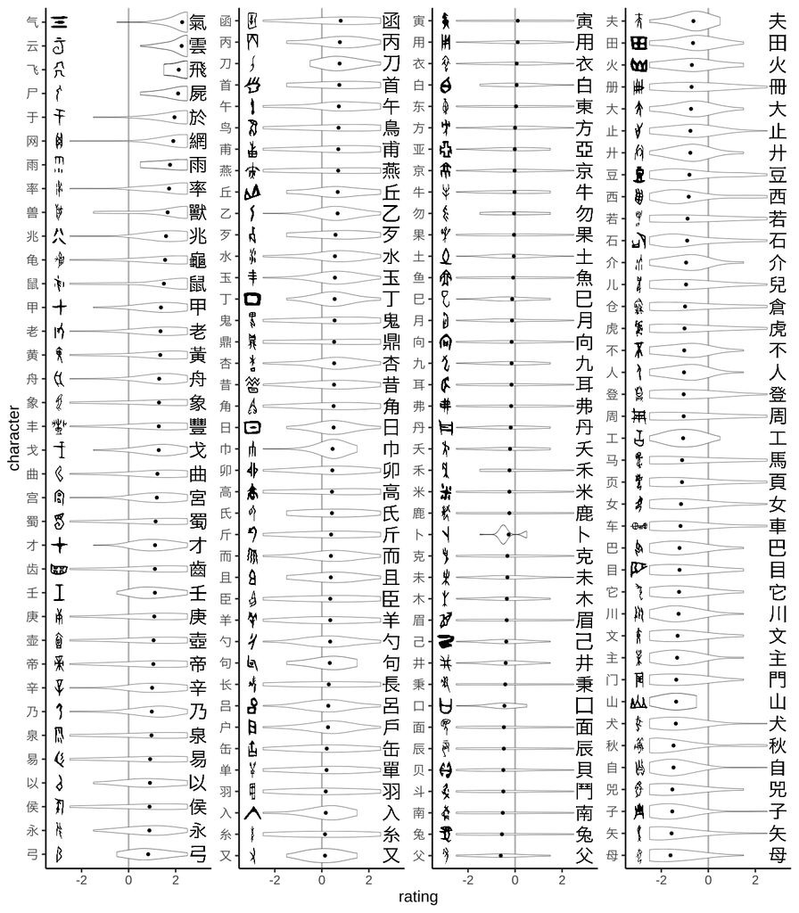

```r
pairplot_printed <- pairplot_hwtrad %+% data_printed
pairplot_printed
```

```r
ggsave(here("figures", "figs4_exp_ratings_bycharacter_printed.png"), plot = pairplot_printed, width = 7,height = 8)
```

Mean ratings for the two conditions compared to each other:

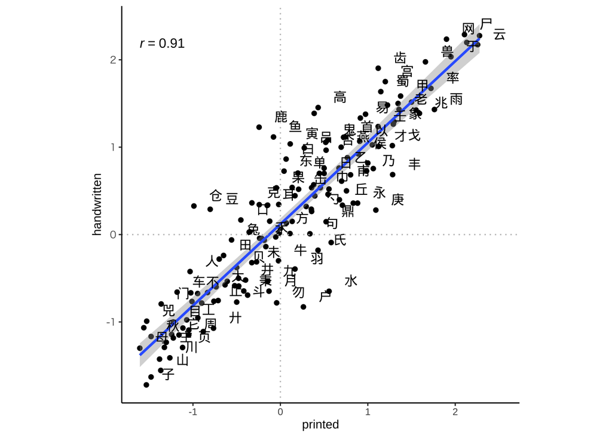

```r
condcompareplot <- expsumm %>%
  select(-r) %>%
  pivot_wider(names_from = condition, values_from = cmean) %>%
  ggplot(aes(printed, handwritten, label=character)) +
  geom_point()  +
  coord_fixed() +
  geom_smooth(method="lm")  +
  geom_text(nudge_x = 0.25, nudge_y = 0.12,  check_overlap = T  ) +
  geom_hline(yintercept=0, linetype='dotted', color="grey") +
  geom_vline(xintercept=0, linetype='dotted', color="grey") +
  stat_cor(
    aes(label = ..r.label..),
    cor.coef.name='r'
  )

condcompareplot
```

There’s a strong relationship, which is reassuring. We can also compare mean human ratings with differences in perimetric complexity (Fig S5)

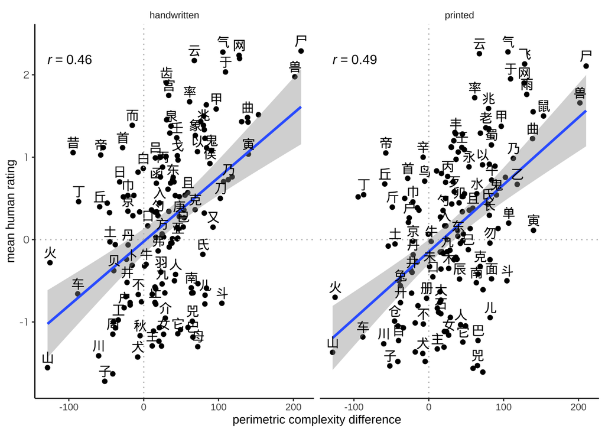

```r
periods <- c( 'Oracle', 'Bronze', 'Seal', 'Traditional', 'Simplified')

cc = converter(S2T)

d_c <- read_csv(dpath_all) %>%
  filter(scale_method==suffix) %>%
  rename(character =simplified_character, complexity= perimetric_complexity) %>%
  mutate(period = factor(period, levels=periods, order=TRUE)) %>%
  group_by(character) %>%
  mutate(first = min(period)) %>%
  filter(first < "Traditional") # only include characters that appear in Seal period or before

dsumm <- d_c %>%
  group_by(character, period, first) %>%
  dplyr::summarize(complexity=median(complexity), .groups="drop") %>%
  mutate(period = factor(period, levels=periods, order=TRUE)) %>%
  right_join(expsumm, by="character")

dsummovstrad <- dsumm %>%
  pivot_wider(names_from="period", values_from = "complexity") %>%
  mutate(tradordiff = Traditional - Oracle)

hvsmod_plot <- dsummovstrad %>%
  ggplot(aes(x=tradordiff, y=cmean, label=character)) +
  geom_point()  +
  geom_smooth(method="lm")  +
  geom_text(nudge_x = 0.25, nudge_y = 0.12,  check_overlap = T  ) +
  geom_hline(yintercept=0, linetype='dotted', color="grey") +
  geom_vline(xintercept=0, linetype='dotted', color="grey")  +
  facet_wrap(~condition) +
  xlab("perimetric complexity difference") +
  ylab("mean human rating") +
  stat_cor(
    aes(label = ..r.label..),
    cor.coef.name='r'
  )

hvsmod_plot
```

```r
ggsave(here("figures", "figs5_exp_ratings_vs_pc.pdf"), plot = hvsmod_plot, width = 6, height = 3)
```

In the printed condition the regression line falls below the intersection of the dotted lines – this suggests that perimetric complexity tends to treat printed characters as more complex than people do. There’s no similar bias for the handwritten condition.

## Statistical tests

We’ll start with the preregistered frequentist analyses. The code here generates Tables S2 and S3. For simplicity, we use logistic regression models, but it might be better to avoid dichotomizing the dependent variable and to treat it as an ordinal variable.

```r
m0 <- glmer(binrating ~ 0 + (1|character) + (1|participantid), data = data_handwritten,  family = binomial(link = "logit"))
m1 <- glmer(binrating ~ 1 + (1|character) + (1|participantid), data = data_handwritten,  family = binomial(link = "logit"))
summary(m1)
```

```
## Generalized linear mixed model fit by maximum likelihood (Laplace
##   Approximation) [glmerMod]
##  Family: binomial  ( logit )
## Formula: binrating ~ 1 + (1 | character) + (1 | participantid)
##    Data: data_handwritten
##
##      AIC      BIC   logLik deviance df.resid
##   7574.1   7595.3  -3784.1   7568.1     8497
##
## Scaled residuals:
##      Min       1Q   Median       3Q      Max
## -16.5843  -0.4343   0.1426   0.4489   9.3821
##
## Random effects:
##  Groups        Name        Variance Std.Dev.
##  participantid (Intercept) 1.237    1.112
##  character     (Intercept) 4.906    2.215
## Number of obs: 8500, groups:  participantid, 170; character, 155
##
## Fixed effects:
##             Estimate Std. Error z value Pr(>|z|)
## (Intercept)   0.5079     0.2007   2.531   0.0114 *
## ---
## Signif. codes:  0 '***' 0.001 '**' 0.01 '*' 0.05 '.' 0.1 ' ' 1
```

```r
a_hw <- anova(m0, m1)
a_hw
```

```
## Data: data_handwritten
## Models:
## m0: binrating ~ 0 + (1 | character) + (1 | participantid)
## m1: binrating ~ 1 + (1 | character) + (1 | participantid)
##    npar    AIC    BIC  logLik deviance  Chisq Df Pr(>Chisq)
## m0    2 7578.4 7592.5 -3787.2   7574.4
## m1    3 7574.1 7595.3 -3784.1   7568.1 6.3088  1    0.01201 *
## ---
## Signif. codes:  0 '***' 0.001 '**' 0.01 '*' 0.05 '.' 0.1 ' ' 1
```

```r
ci_intercept <- confint(m1)
ci_intercept
```

```
##                 2.5 %    97.5 %
## .sig01      0.9816977 1.2651693
## .sig02      1.9613875 2.5198468
## (Intercept) 0.1132964 0.9041671
```

```r
aprint_hw <- a_hw %>%
    select(AIC, BIC, Chisq, Df, `Pr(>Chisq)`) %>%
    rownames_to_column() %>%
    rename(model=rowname) %>%
    mutate(model = recode(model, "m0"="0 + (1|character) + (1|participantID)",
                                 "m1"= "1 + (1|character) + (1|participantID)")) %>%
    mutate( `Pr(>Chisq)` = as.character(signif(`Pr(>Chisq)`, digits=3)))
  mstable <- xtable(aprint_hw, caption = paste0("Comparison between models with and without an intercept. The dependent variable is human ratings of the complexity of handwritten traditional characters relative to Oracle forms."), label = "tab:regtable_exp_hw")
  print(mstable, file = here("tables", "tabs2_regtable_exp_hw.tex"), include.rownames = FALSE)
```

This tells us that for the handwritten condition, people’s responses are significantly different from chance (p = 0.012) in the direction that we predicted.

```r
m0 <- glmer(binrating ~ 0 + (1|character) + (1|participantid), data = data_printed,  family = binomial(link = "logit"))
m1 <- glmer(binrating ~ 1 + (1|character) + (1|participantid), data = data_printed,  family = binomial(link = "logit"))
summary(m1)
```

```
## Generalized linear mixed model fit by maximum likelihood (Laplace
##   Approximation) [glmerMod]
##  Family: binomial  ( logit )
## Formula: binrating ~ 1 + (1 | character) + (1 | participantid)
##    Data: data_printed
##
##      AIC      BIC   logLik deviance df.resid
##   5752.2   5772.5  -2873.1   5746.2     6597
##
## Scaled residuals:
##     Min      1Q  Median      3Q     Max
## -9.0210 -0.4081  0.0724  0.4237 14.2303
##
## Random effects:
##  Groups        Name        Variance Std.Dev.
##  character     (Intercept) 5.458    2.336
##  participantid (Intercept) 2.572    1.604
## Number of obs: 6600, groups:  character, 155; participantid, 132
##
## Fixed effects:
##             Estimate Std. Error z value Pr(>|z|)
## (Intercept)   0.1869     0.2374   0.787    0.431
```

```r
a_printed <- anova(m0, m1)
a_printed
```

```
## Data: data_printed
## Models:
## m0: binrating ~ 0 + (1 | character) + (1 | participantid)
## m1: binrating ~ 1 + (1 | character) + (1 | participantid)
##    npar    AIC    BIC  logLik deviance  Chisq Df Pr(>Chisq)
## m0    2 5750.8 5764.4 -2873.4   5746.8
## m1    3 5752.2 5772.5 -2873.1   5746.2 0.6179  1     0.4318
```

```r
ci_intercept <- confint(m1)
ci_intercept
```

```
##                  2.5 %    97.5 %
## .sig01       2.0616292 2.6658973
## .sig02       1.4035264 1.8458939
## (Intercept) -0.2800566 0.6549618
```

```r
aprint_printed <- a_printed %>%
    select(AIC, BIC, Chisq, Df, `Pr(>Chisq)`) %>%
    rownames_to_column() %>%
    rename(model=rowname) %>%
    mutate(model = recode(model, "m0"="0 + (1|character) + (1|participantID)",
                                 "m1"= "1 + (1|character) + (1|participantID)")) %>%
    mutate( `Pr(>Chisq)` = as.character(signif(`Pr(>Chisq)`, digits=3)))

  mstable <- xtable(aprint_printed, caption = paste0("Comparison between models with and without an intercept. The dependent variable is human ratings of the complexity of printed traditional characters relative to Oracle forms."), label = "tab:regtable_exp_printed")
  print(mstable, file = here("tables", "tabs3_regtable_exp_printed.tex"), include.rownames = FALSE)
```

The effect for the printed condition is not significant (p = 0.43).

And now for the Bayesian analyses

```r
nchain <- 4
niter <- 4000

fit_handwritten <- brm( binrating ~ 1 + (1|character) + (1|participantid), family=bernoulli(), data = data_handwritten, chains = nchain, iter = niter )
brms_tab_hw <- fixef(fit_handwritten) %>% as_tibble(rownames="NA")

brms_tab_hw
```

```
## # A tibble: 1 × 5
##   `NA`      Estimate Est.Error  Q2.5 Q97.5
##   <chr>        <dbl>     <dbl> <dbl> <dbl>
## 1 Intercept    0.508     0.205 0.102 0.906
```

The 95% credibility interval on the intercept is [0.1, 0.91]. Because this interval excludes zero, our hypothesis is supported.

```r
fit_printed <- brm( binrating ~ 1 + (1|character) + (1|participantid), family=bernoulli(), data = data_printed, chains = nchain, iter = niter )
brms_tab_printed <- fixef(fit_printed) %>% as_tibble(rownames="NA")

brms_tab_printed
```

```
## # A tibble: 1 × 5
##   `NA`      Estimate Est.Error   Q2.5 Q97.5
##   <chr>        <dbl>     <dbl>  <dbl> <dbl>
## 1 Intercept    0.185     0.226 -0.261 0.630
```

The 95% credibility interval on the intercept is [-0.26, 0.63].